# Differential abundance analysis — T2D vs Healthy (Chinese cohort)

## Phylogenetic context of the differential genera

W20-01 attaches a phylogenetic tree to the phyloseq object and visualises it with `plot_tree()`. Here we reuse that to ask a community-level question: **are the T2D-associated and Healthy-associated genera scattered across the tree, or clustered in particular lineages?** Lineage clustering would suggest the disease signal tracks a coarse phylogenetic/functional group (e.g. a whole clade of fibre fermenters) rather than scattered individual genera.

Each tip is coloured by its direction in the **primary CLR model** (adjusted for Sex + Age). Samples are merged into the two disease groups so the abundance points stay readable (two points per tip instead of 359).

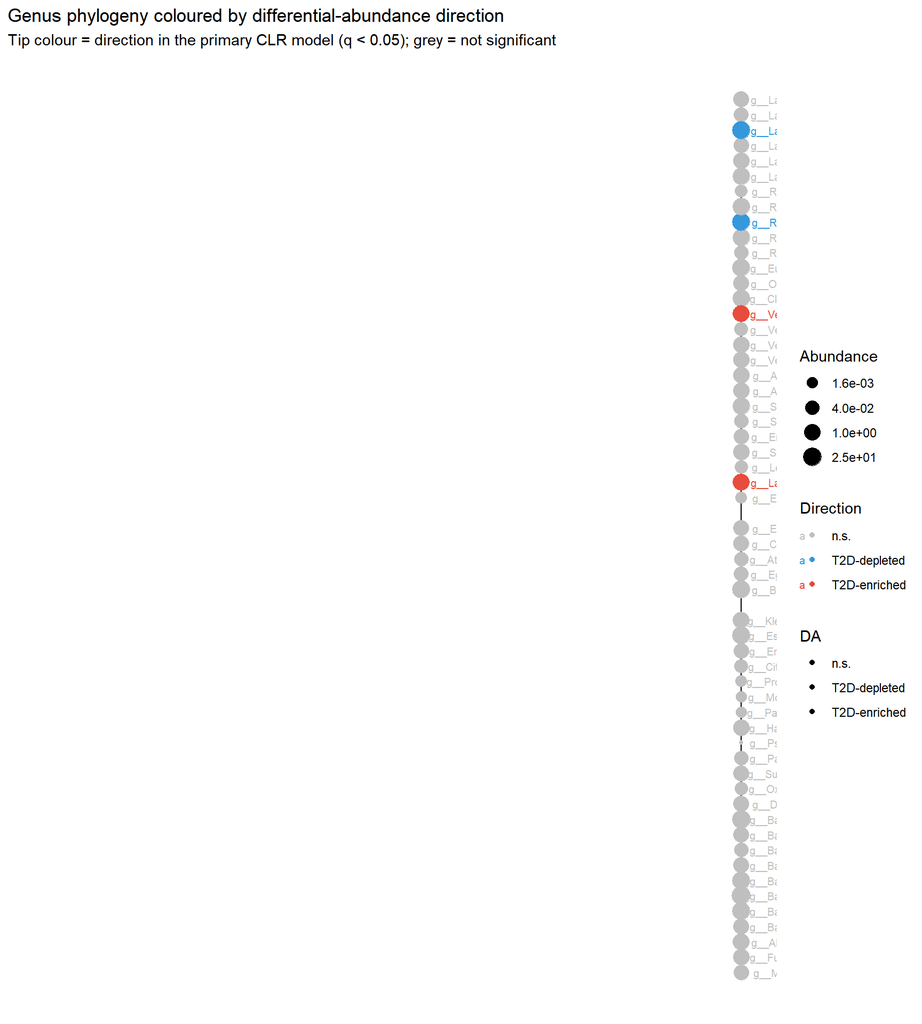

```r
# Direction + significance per genus, taken from the primary CLR-adjusted model
da_dir <- clr_disease_adjusted_sex_results %>%
  transmute(
    taxon,
    DA = case_when(
      q_value < 0.05 & estimate > 0 ~ "T2D-enriched",
      q_value < 0.05 & estimate < 0 ~ "T2D-depleted",
      TRUE                          ~ "n.s."
    )
  )

# Splice the DA label into the taxonomy table of the genus object (which carries the tree)
tt <- as.data.frame(as(tax_table(ps), "matrix")) %>%
  rownames_to_column("taxon") %>%
  left_join(da_dir, by = "taxon") %>%
  mutate(DA = ifelse(is.na(DA), "n.s.", DA))

ps_tree <- ps
tax_table(ps_tree) <- phyloseq::tax_table(
  tt %>% column_to_rownames("taxon") %>% as.matrix()
)

# Merge to the two disease groups so plot_tree shows 2 abundance points per tip, not 359
ps_tree_grp <- merge_samples(ps_tree, group = "Disease.MESH.ID")

plot_tree(
  ps_tree_grp,
  color      = "DA",
  label.tips = "Genus",
  ladderize  = "left",
  size       = "abundance",
  text.size  = 2.6
) +
  scale_color_manual(values = c(
    "T2D-enriched" = "#E74C3C",
    "T2D-depleted" = "#3498DB",
    "n.s."         = "grey75"
  )) +
  labs(title = "Genus phylogeny coloured by differential-abundance direction",
       subtitle = "Tip colour = direction in the primary CLR model (q < 0.05); grey = not significant",
       color = "Direction")
```

> *Taught in: W20-01 §“Visualising the phylogenetic tree” (`plot_tree`, tree attached to the phyloseq object) and §“Agglomerating taxa” (`tax_table` manipulation + `make.unique`). Colouring tips by a `tax_table` column and `merge_samples` are taught phyloseq operations (W20-01 handling section). The DA direction column is spliced in from the CLR model (W21 §9).*

> **Caveat (read before interpreting):** the attached tree is a GTDB **taxonomy cladogram** — its branch lengths are almost all zero. So this figure shows *taxonomic* grouping (who sits in which family/order), **not** true evolutionary distance, and should be read as “are the differential genera taxonomically clustered?” rather than as a phylogenetic-distance statement. This is also why we do not compute UniFrac (see `beta_diversity.Rmd`).

```r
# Inside one of the Rmds
meta_check <- data.frame(sample_data(ps))

summary(meta_check$BMI)
```

```
##    Min. 1st Qu.  Median    Mean 3rd Qu.    Max.    NA's
##   16.00   19.47   20.90   22.57   25.62   32.58     208
```

```r
summary(meta_check$Host.age)
```

```
##    Min. 1st Qu.  Median    Mean 3rd Qu.    Max.
##   13.00   40.00   49.00   48.59   58.00   86.00
```

```r
table(meta_check$Recent.antibiotics.use, useNA = "ifany")
```

```
##
##   N
## 359
```

```r
table(meta_check$Sex)
```

```
##
## Female   Male
##    149    210
```

```r
# How many samples have complete covariates?
complete_cases_n <- meta_check %>%
  filter(!is.na(BMI), !is.na(Host.age), !is.na(Sex), !is.na(Recent.antibiotics.use)) %>%
  nrow()

complete_cases_n
```

```
## [1] 151
```

> *Project-chosen housekeeping (not a taught method): plain `summary()`/`table()`/NA-count checks on the metadata, used to justify the covariate choices (Sex + Host.age complete; antibiotics monomorphic; BMI 58% missing). Inspecting `sample_data` is taught in W20-01.*